# Schooling and Wages LASSO Analysis

Robert C Phillips

February 20, 2016

### Introduction

The purpose of this assignment is to run a lasso regression analysis using k-fold cross validation to identify a subset of predictors from a larger pool of predictor variables that best predicts the quantitative response variable. I am using R for this analysis as an additional challenge since Python and SAS solutions were already provided within the lectures.

For this analysis I am using the “Wages and Schooling” dataset provided here: http://vincentarelbundock.github.io/Rdatasets/doc/Ecdat/Schooling.html.

```r
data <- read.csv("Schooling.csv")
```

The variables included in this dataset are:

- X: observation identifier
- smsa66: lived in smsa in 1966 ?
- smsa76: lived in smsa in 1976 ?
- nearc2: grew up near 2-yr college ?
- nearc4: grew up near 4-yr college ?
- nearc4a: grew up near 4-year public college ?
- nearc4b: grew up near 4-year private college ?
- ed76: education in 1976
- ed66: education in 1966
- age76: age in 1976
- daded: dads education (imputed avg if missing)
- nodaded: dads education imputed ?
- momed: mothers education
- nomomed: moms education imputed ?
- momdad14: lived with mom and dad at age 14 ?
- sinmom14: single mom at age 14 ?
- step14: step parent at age 14 ?
- south66: lived in south in 1966 ?
- south76: lived in south in 1976 ?
- lwage76: log wage in 1976 (outliers trimmed)
- famed: mom-dad education class (1-9)
- black: black ?
- wage76: wage in 1976 (raw, cents per hour)
- enroll76: enrolled in 1976 ?
- kww: the kww score
- iqscore: a normed IQ score
- mar76: married in 1976 ?
- libcrd14: library card in home at age 14 ?
- exp76: experience in 1976

The target variable for this analysis will be the **wage76** variable.

### Exploratory Analysis

Summarizing the data indcates the varables **kww**, **iqscore**, **mar76** and **libcrd14** contain missing values.

```r
summary(data)
```

```
##        X          smsa66     smsa76     nearc2     nearc4     nearc4a
##  Min.   :   1.0   no :1055   no : 864   no :1683   no : 957   no :1527
##  1st Qu.: 753.2   yes:1955   yes:2146   yes:1327   yes:2053   yes:1483
##  Median :1505.5
##  Mean   :1505.5
##  3rd Qu.:2257.8
##  Max.   :3010.0
##
##  nearc4b         ed76            ed66           age76
##  no :2440   Min.   : 1.00   Min.   : 0.00   Min.   :24.00
##  yes: 570   1st Qu.:12.00   1st Qu.: 9.00   1st Qu.:25.00
##             Median :13.00   Median :11.00   Median :28.00
##             Mean   :13.26   Mean   :10.76   Mean   :28.12
##             3rd Qu.:16.00   3rd Qu.:12.00   3rd Qu.:31.00
##             Max.   :18.00   Max.   :18.00   Max.   :34.00
##
##      daded        nodaded        momed       nomomed    momdad14
##  Min.   : 0.000   no :2320   Min.   : 0.00   no :2320   no : 634
##  1st Qu.: 8.000   yes: 690   1st Qu.: 9.00   yes: 690   yes:2376
##  Median : 9.940              Median :11.00
##  Mean   : 9.989              Mean   :10.34
##  3rd Qu.:12.000              3rd Qu.:12.00
##  Max.   :18.000              Max.   :18.00
##
##  sinmom14   step14     south66    south76       lwage76
##  no :2707   no :2893   no :1763   no :1795   Min.   :4.605
##  yes: 303   yes: 117   yes:1247   yes:1215   1st Qu.:5.977
##                                              Median :6.287
##                                              Mean   :6.262
##                                              3rd Qu.:6.564
##                                              Max.   :7.785
##
##      famed       black          wage76       enroll76        kww
##  Min.   :1.000   no :2307   Min.   : 100.0   no :2732   Min.   : 4.00
##  1st Qu.:3.000   yes: 703   1st Qu.: 394.2   yes: 278   1st Qu.:28.00
##  Median :6.000              Median : 537.5              Median :34.00
##  Mean   :5.934              Mean   : 577.3              Mean   :33.54
##  3rd Qu.:8.000              3rd Qu.: 708.8              3rd Qu.:40.00
##  Max.   :9.000              Max.   :2404.0              Max.   :56.00
##                                                         NA's   :47
##     iqscore       mar76      libcrd14        exp76
##  Min.   : 50.0   2   :  14   no  : 976   Min.   : 0.000
##  1st Qu.: 93.0   3   :   3   yes :2021   1st Qu.: 6.000
##  Median :103.0   4   : 155   NA's:  13   Median : 8.000
##  Mean   :102.4   5   : 102               Mean   : 8.856
##  3rd Qu.:113.0   6   : 585               3rd Qu.:11.000
##  Max.   :149.0   yes :2144               Max.   :23.000
##  NA's   :949     NA's:   7
```

One of the goals of LASSO is to aid in model selection by indicating the subset of variables that best predict the target. Therefore we don’t want to remove variables for this initial analysis.

The variable **iqscore** would be interesting to include, but is missing for almost 1/3 of the observations. The other variables have a low number of missing values, therefore we’ll filter out those observations so that we can include them in the LASSO analysis.

```r
#remove the iqscore variable
data$iqscore <- NULL

#remove observations with NA values
data <- na.omit(data)
```

Additionally, all quantitative variables to be used as a predictor appear to be on the same scale, thefore no preprocessing is necessary.

### LASSO Analysis

We will use the **glmnet** package in R for this analysis. This method requires a matrix for the predictors and a seperate vector for the target variable. We will establish those items as the variables X and Y. Furthermore, we need to split the data into a training and test set.

```r
#define the model with wage76 as the target
model1 <- wage76 ~ smsa66 + smsa76 + nearc2 + nearc4 + nearc4a + nearc4b + ed76 + ed66 + age76 +
                   daded + nodaded + momed + nomomed + momdad14 + sinmom14 + step14 + south66 + south76 +
                   famed + black + enroll76 + kww + mar76 + libcrd14 + exp76

#build the matrix and vector required by glmnet
X <- model.matrix(model1, data)[,-1]
Y <- data$wage76

#split into training and test sets
set.seed(1972)
train.rows <- sample(1:nrow(X), nrow(X) / 2)
test.rows <- (-train.rows)

X.train <- X[train.rows,]
Y.train <- Y[train.rows]

X.test <- X[test.rows,]
Y.test <- Y[test.rows]
```

Now that we have our training and test data we can run the LASSO analysis. We first build the LASSO model and review the coefficient plot.

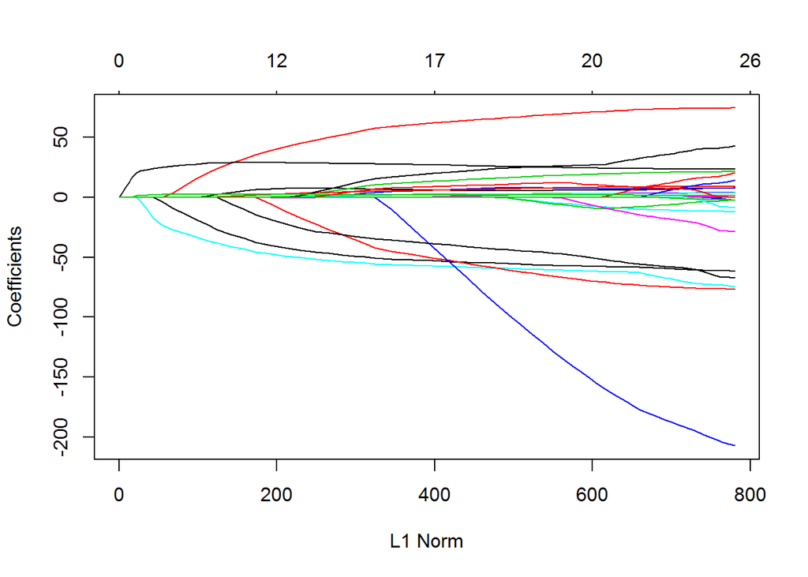

```r
require(glmnet)

#alpha = 1 for LASSO
lasso1 <- glmnet(X.train, Y.train , alpha=1)
plot(lasso1)
```

We can then use cross-validation to determine an optimal value of lambda. This also allows us to review how the MSE changes as lambda changes.

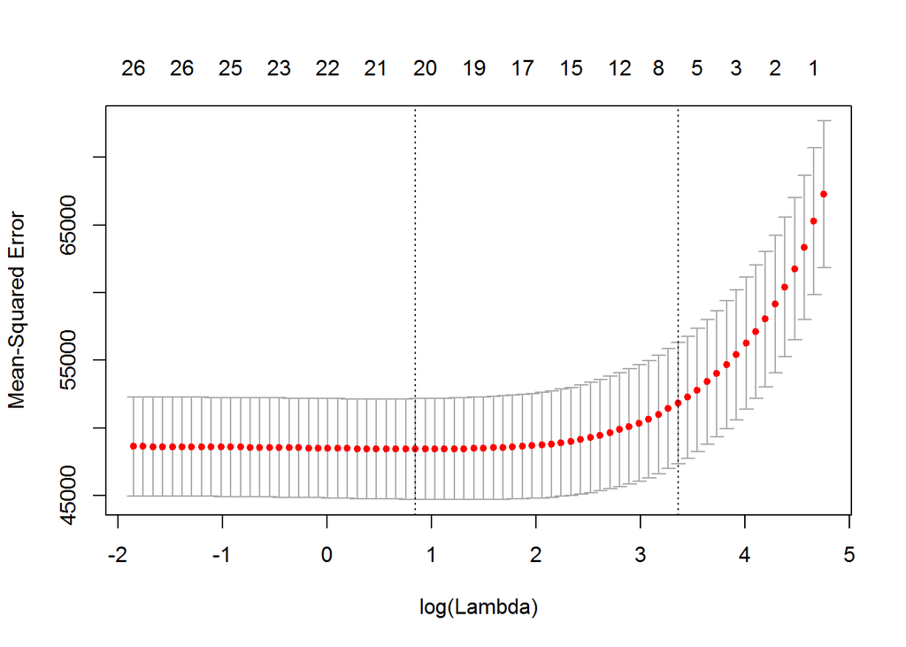

```r
set.seed(1990)
lasso1.cv <- cv.glmnet(X.train, Y.train, alpha=1)
plot(lasso1.cv)
```

We can use the optimal value of lambda to perform prediction.

```r
#use the minimum lambda value for prediction and calculate the MSE
lasso1.lambda <- lasso1.cv$lambda.min
lasso1.pred <- predict(lasso1, s=lasso1.lambda, newx=X.test)
lasso1.mse <- mean((lasso1.pred - Y.test)^2)
```

A lambda value of **2.3349556** yields a MSE of **4.930610^{4}**.

We can also review the coefficients using this value of lambda.

```r
#get the coefficients for the best lambda value
lasso1.coef <- predict(lasso1, type="coefficients", s=lasso1.lambda)[1:20,]
lasso1.coef
```

```
## (Intercept)   smsa66yes   smsa76yes   nearc2yes   nearc4yes  nearc4ayes
## -116.228026    6.053347   70.262457   18.742618    0.000000    7.564165
##  nearc4byes        ed76        ed66       age76       daded  nodadedyes
##   -5.710730    2.754336   24.758100    8.062385    2.933716    0.000000
##       momed  nomomedyes momdad14yes sinmom14yes   step14yes  south66yes
##    2.812760    0.000000   26.560778    0.000000   -7.121788    0.000000
##  south76yes       famed
##  -61.142965    0.000000
```

The result is that the coefficients for the variables **nearc4(yes)**, **nodaded(yes)**, **nomomed(yes)**, **sinmom14(yes)**, **south66(yes)**, and **famed** are set to 0, indicating they may not be good predictors. Furthermore, variables such as **smsa76(yes)**, **nearc2(yes)**, **ed66**, and **momdad14(yes)** have a positive impact on wages whereas the variables **south76(yes)**, **step14(yes)**, **nearc4b(yes)** appear to have a negative impact on wages.

### Summary

The LASSO approach quickly provides a subset of variables that may be best for prediction. Using standard linear regression may have required numerous runs and analysis to arrive an optimal subset of predictors.

For fun, let’s use the noted non-zero coefficents in a linar model.

```r
model2 <- wage76 ~ smsa76 + nearc2 + ed66 + momdad14 + south76 + step14 + nearc4b

fit1 <- lm(model2, data[train.rows,])
summary(fit1)
```

```
##
## Call:
## lm(formula = model2, data = data[train.rows, ])
##
## Residuals:
##     Min      1Q  Median      3Q     Max
## -589.08 -137.95  -19.34  105.24 1571.91
##
## Coefficients:
##             Estimate Std. Error t value Pr(>|t|)
## (Intercept)   46.513     33.361   1.394  0.16345
## smsa76yes     72.681     13.207   5.503 4.40e-08 ***
## nearc2yes     21.933     12.219   1.795  0.07286 .
## ed66          43.221      2.585  16.718  < 2e-16 ***
## momdad14yes   46.731     16.116   2.900  0.00379 **
## south76yes   -83.537     12.427  -6.722 2.56e-11 ***
## step14yes    -11.652     31.831  -0.366  0.71437
## nearc4byes   -12.118     15.472  -0.783  0.43361
## ---
## Signif. codes:  0 '***' 0.001 '**' 0.01 '*' 0.05 '.' 0.1 ' ' 1
##
## Residual standard error: 224 on 1464 degrees of freedom
## Multiple R-squared:  0.2586, Adjusted R-squared:  0.2551
## F-statistic: 72.96 on 7 and 1464 DF,  p-value: < 2.2e-16
```

```r
fit1.pred <- predict(fit1, data[test.rows,])
fit1.mse <- mean((fit1.pred - data[test.rows,"wage76"])^2)
```

This model yields an MSE of **5.283835310^{4}** which is higher than the LASSO model. Also interesting is that both models are consistent in indicating which variables have a positive impact and which have a negative impact. However, variables such as **step14** and **nearc4** have high p-values which indicates they may not be useful in the model. All of this information can be used in subsequent analysis and model building.